# Project1Report

#### Project 1

## Visualization and Analysis of the Drosophila Optic Medulla Connectome

#### Introduction

*This is the abstract of the paper written about this dataset*

Animal behaviour arises from computations in neuronal circuits, but our understanding of these computations has been frustrated by the lack of detailed synaptic connection maps, or connectomes. For example, despite intensive investigations over half a century, the neuronal implementation of local motion detection in the insect visual system remains elusive. Here we develop a semi-automated pipeline using electron microscopy to reconstruct a connectome, containing 379 neurons and 8,637 chemical synaptic contacts, within the Drosophila optic medulla. By matching reconstructed neurons to examples from light microscopy, we assigned neurons to cell types and assembled a connectome of the repeating module of the medulla. Within this module, we identified cell types constituting a motion detection circuit, and showed that the connections onto individual motion-sensitive neurons in this circuit were consistent with their direction selectivity. Our results identify cellular targets for future functional investigations, and demonstrate that connectomes can provide key insights into neuronal computations.

Brain network analysis is a new and growing field. We are at an interesting time in histroy where we have extremely advanced imaging technology with electron microscopes and fMRIs but our map of the brain is very similar to our map of the brain from 100 years ago. As network analysis grows as a field, discorveries in neuroscience are rapidly advancing. In my project I will visualize and analyse the anatomical network of the Drosophila (Common Fruit Fly) Optic Medulla Connectome (Network of Neurons). Through out my analysis I will be looking to find out which nodes are most important/will cause the most damage when removed. I will also be asking come questions about communities, centrality and other network properties. This will give us insight into the nature of Brain Networks.

#### Connections are important! Nodal Properties

###### Structural - looks at regons and pathways that connect them

###### Functional - how different parts of the brain work together

We will look at structural in the context of this network/connectome. In this network of 1800 nodes, the average degree is 37. The average density is 0.0211395. Degree is not distributed homogeneously across the nodes of brain networks; instead, some nodes have a very high degree, marking them as network hubs. Looking at modularity using Gephi we are able to find 11 unique communities. (Denoted by color in our network visualization.)

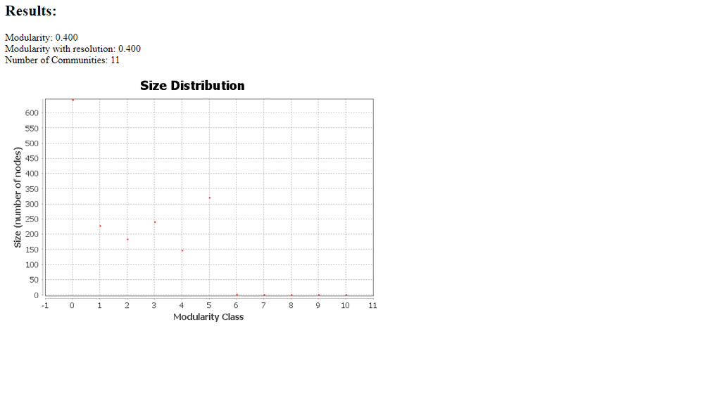

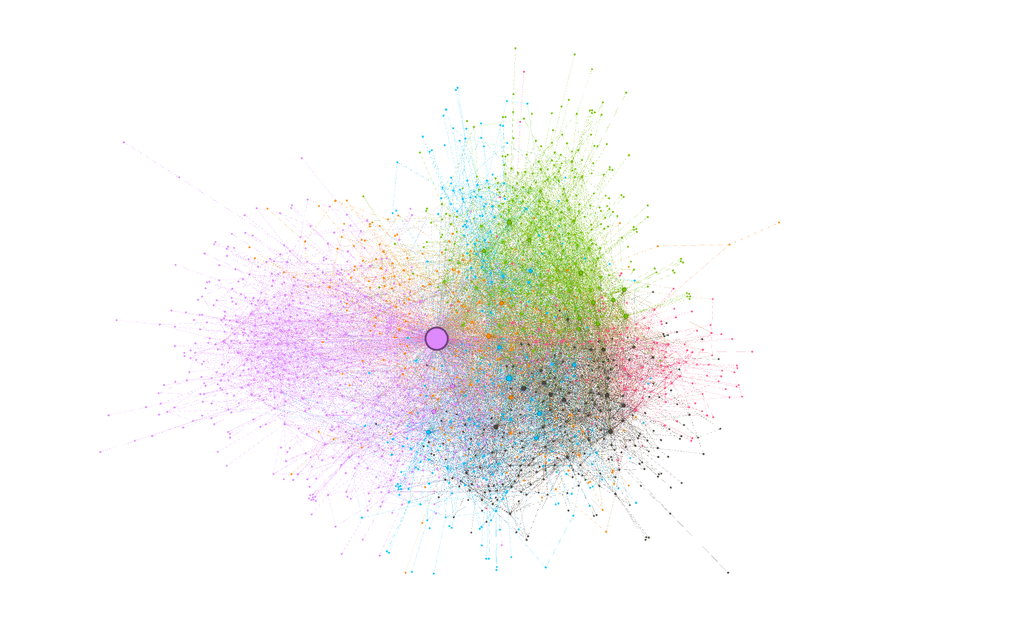

```
In this visualization, the nodes are sized by degree. This shows us that there is one node in the purple group that is involved in connecting all the other groups. The differnece in degree is between the biggest hub and other hubs is huge.
```

Hubs are importantant because they often interact with many other regions, facilitate functional intergration, and play a key role in network resilence to insult(how well they adapt to damage). We can identify hubs by looking at degree or betweenness. Betweennes is how many times a node appears in another nodes shortest path. Nodes with high degrees/betweenness are going to be our hubs.

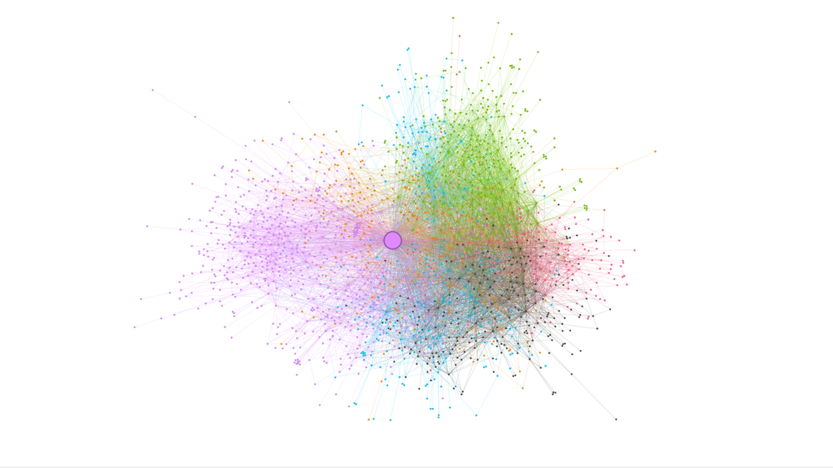

```
This visualzation is sized by betweenness, we see the same node from the purple group have a high betweenness as well as degree. This node must be extremely important to function and structure of the connectome
```

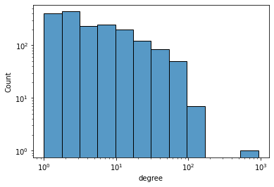

Degree has a straightforward neurobiological interpretation, nodes with a high degree are interacting, structurally or functionally with many other nodes in the network.

In our network of 33.5 thousand edges, we identified 403 to be bridges.

Bridges are the only edge that connect two separate components making them extremely important to the networks function as a whole.

Individual central nodes that score lowly on these measures may therefore compromise global network function if disrupted.

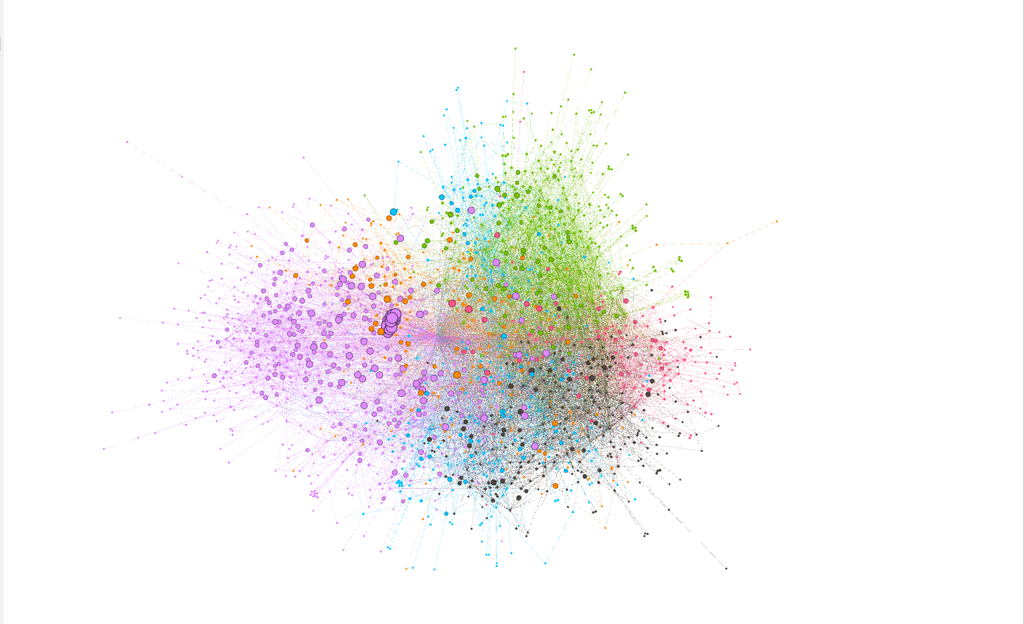

```
This visualization of the connectome is sized by Average Neighbor Degree
```

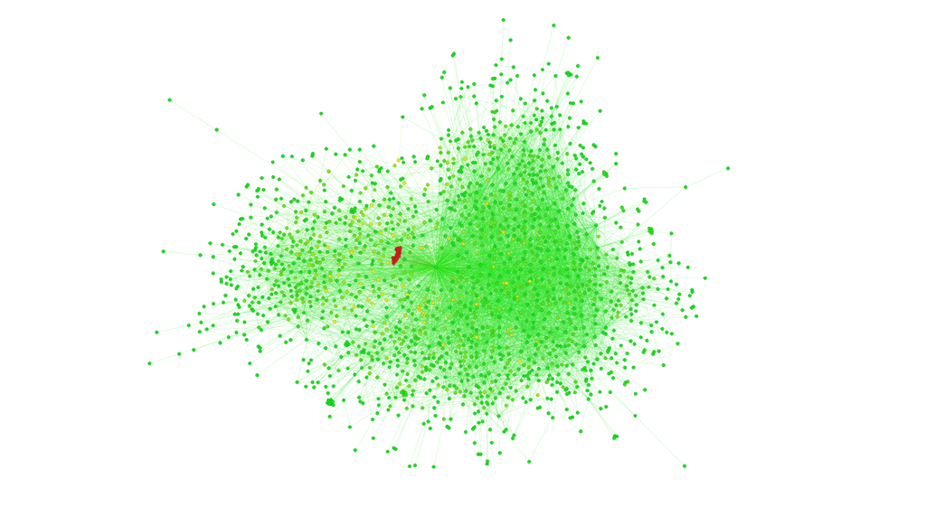

```
This visualization is colored by average neighbor degree, with the red ones being the most damaging to the funcation of the network if removed
```

Individual central nodes that score lowly on these measures may therefore compromise global network function if disrupted.

#### Network Properties

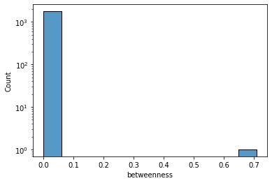

Is is a small world network?

In network neuroscience, it has been found that most brain networks or connectomes exhibit features of small world networks. Loss of the small world feature is a signiture of diseases like Alzheimer and Schizophernia. To see if our fly optical medula is a small world network, we will look at clustering coeffcient and average shortest path length.

The average clustering coeffcient of the network is 0.2628486923268566. This number is closer to 0 than 1 so I would say it is not a high clustering coeffcient, this is not what we would expect in a small world network.

When I went to calculate the shortest path length I got an error that led me to check if the network was connected and that returned false. I am not sure why I have a network that is not connected, maybe this is why the clustering coeffcient is lower than expected. I check the average path length in Gephi and I got:

```
Results:

Diameter: 6

Radius: 1

Average Path length: 2.910526631799751
```

Which would be consistant with a small world network. Because on average you can get to any other node in 3 or less jumps.

#### Types of connectivity

Lattice -> Complex -> Random  
<------ Cost ---------  
Low High  
---- Efficency ------>

A lattice connection is like a straight line of nodes. This is effcient in wiring costs but not effcient in processing of information. Complex would be similar to a small world network where there is some kind of underlying complex pattern that allows the nodes to be better interconnected but cost a little bit more in resources (myelin sheet, axon, dendtrites etc). A complete random set of connections is very effcient for allowing different parts of the brain to communicate with each other but are very costly since you might not be using all of the pathways all of the time.

Looking at our network with the nodes sized by clustering coeffcient allows us to explore the connection patters of this flys optical medula. Areas around the big nodes exhibit complex connectivity since they are used often and need ease of access from any other node in the brain. The smaller nodes near the outside of the visualation exhibit a type of Lattice connection since they are only accessed from one or two places and only send information back to one or two places.

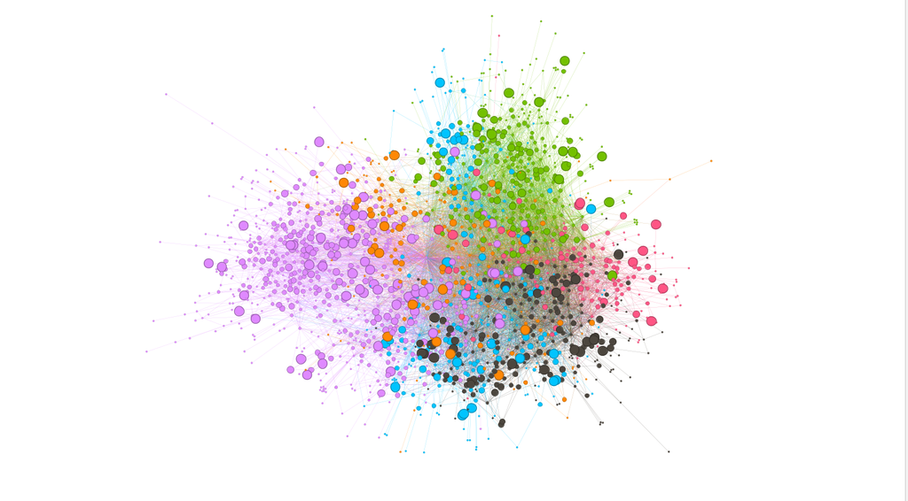

The clustering coefficent quantifies the abundance of connected triangles in a network. In network neuroscience, the clustering coeffcient has been shown to be useful in quantity for understanding function-structure associations.

##### Conclusion

Analysis of the Drosophila Optic Medulla Connectome yeilded some interesting results. We found 11 moduals that could represent 11 functionally different compantents in the netwrok. We found some hubs and other non-hub important nodes that might change or inhib certain functions if removed. We also found that this network exhibits properties of a small world network. This is because it allows for the most effcient processing of information with the least amount of wiring costs. Understanding how brain networks make these choices of connecting nodes and edges from different parts of the brain will help us learn more about the brain but also graph theory as we try to explain new phenoma we observe as the field prgresses.